# Kaggle:Yelp:Restaurant Features: outdoor label classification:: YelpRest_nImgs_outside

```r
if (!is.null(glbFeatsCategory)) {
    glbLvlCategory <- merge(glbLvlCategory,
            myget_category_stats(obs_df = glbObsFit, mdl_id = glb_sel_mdl_id,
                                 label = "fit"),
                            by = glbFeatsCategory, all = TRUE)
    row.names(glbLvlCategory) <- glbLvlCategory[, glbFeatsCategory]
    glbLvlCategory <- merge(glbLvlCategory,
            myget_category_stats(obs_df = glbObsOOB, mdl_id = glb_sel_mdl_id,
                                 label="OOB"),
                          #by=glbFeatsCategory, all=TRUE) glb_ctgry-df already contains .n.OOB ?
                          all = TRUE)
    row.names(glbLvlCategory) <- glbLvlCategory[, glbFeatsCategory]
    if (any(grepl("OOB", glbMdlMetricsEval)))
        print(orderBy(~-err.abs.OOB.mean, glbLvlCategory)) else
            print(orderBy(~-err.abs.fit.mean, glbLvlCategory))
    print(colSums(glbLvlCategory[, -grep(glbFeatsCategory, names(glbLvlCategory))]))
}
```

```
##             nImgs.cut.fctr .n.OOB .n.Fit .n.Tst .freqRatio.Fit
## (32,60]            (32,60]    243    278   2512      0.2774451
## (60,120]          (60,120]    260    257   2459      0.2564870
## (120,3e+03]    (120,3e+03]    258    229   2497      0.2285429
## (0,32]              (0,32]    237    238   2532      0.2375250
##             .freqRatio.OOB .freqRatio.Tst err.abs.fit.sum err.abs.fit.mean
## (32,60]          0.2434870         0.2512        138.4758        0.4981144
## (60,120]         0.2605210         0.2459        128.1983        0.4988260
## (120,3e+03]      0.2585170         0.2497        111.9129        0.4887026
## (0,32]           0.2374749         0.2532        115.5277        0.4854105
##             .n.fit err.abs.OOB.sum err.abs.OOB.mean
## (32,60]        278        121.1463        0.4985443
## (60,120]       257        129.4236        0.4977832
## (120,3e+03]    229        128.1028        0.4965226
## (0,32]         238        116.7779        0.4927339
##           .n.OOB           .n.Fit           .n.Tst   .freqRatio.Fit
##       998.000000      1002.000000     10000.000000         1.000000
##   .freqRatio.OOB   .freqRatio.Tst  err.abs.fit.sum err.abs.fit.mean
##         1.000000         1.000000       494.114699         1.971054
##           .n.fit  err.abs.OOB.sum err.abs.OOB.mean
##      1002.000000       495.450675         1.985584
```

```r
write.csv(glbObsOOB[, c(glbFeatsId,
                grep(glb_rsp_var, names(glbObsOOB), fixed=TRUE, value=TRUE))],
    paste0(gsub(".", "_", paste0(glbOut$pfx, glb_sel_mdl_id), fixed=TRUE),
           "_OOBobs.csv"), row.names=FALSE)

fit.models_2_chunk_df <-
    myadd_chunk(NULL, "fit.models_2_bgn", label.minor = "teardown")
```

```
##              label step_major step_minor label_minor     bgn end elapsed
## 1 fit.models_2_bgn          1          0    teardown 110.968  NA      NA
```

```r
glb_chunks_df <- myadd_chunk(glb_chunks_df, "fit.models", major.inc=FALSE)
```

```
##         label step_major step_minor label_minor     bgn     end elapsed
## 18 fit.models          8          2           2  98.090 110.981  12.891
## 19 fit.models          8          3           3 110.982      NA      NA
```

```r
# if (sum(is.na(glbObsAll$D.P.http)) > 0)
#         stop("fit.models_3: Why is this happening ?")

#stop(here"); glb2Sav()
sync_glb_obs_df <- function() {
    # Merge or cbind ?
    for (col in setdiff(names(glbObsFit), names(glbObsTrn)))
        glbObsTrn[glbObsTrn$.lcn == "Fit", col] <<- glbObsFit[, col]
    for (col in setdiff(names(glbObsFit), names(glbObsAll)))
        glbObsAll[glbObsAll$.lcn == "Fit", col] <<- glbObsFit[, col]
    if (all(is.na(glbObsNew[, glb_rsp_var])))
        for (col in setdiff(names(glbObsOOB), names(glbObsTrn)))
            glbObsTrn[glbObsTrn$.lcn == "OOB", col] <<- glbObsOOB[, col]
    for (col in setdiff(names(glbObsOOB), names(glbObsAll)))
        glbObsAll[glbObsAll$.lcn == "OOB", col] <<- glbObsOOB[, col]
}
sync_glb_obs_df()

print(setdiff(names(glbObsNew), names(glbObsAll)))
```

```
## character(0)
```

```r
replay.petrisim(pn=glb_analytics_pn,
    replay.trans=(glb_analytics_avl_objs <- c(glb_analytics_avl_objs,
        "model.selected")), flip_coord=TRUE)
```

```
## time trans    "bgn " "fit.data.training.all " "predict.data.new " "end "
## 0.0000   multiple enabled transitions:  data.training.all data.new model.selected    firing:  data.training.all
## 1.0000    1   2 1 0 0
## 1.0000   multiple enabled transitions:  data.training.all data.new model.selected model.final data.training.all.prediction   firing:  data.new
## 2.0000    2   1 1 1 0
## 2.0000   multiple enabled transitions:  data.training.all data.new model.selected model.final data.training.all.prediction data.new.prediction   firing:  model.selected
## 3.0000    3   0 2 1 0
```

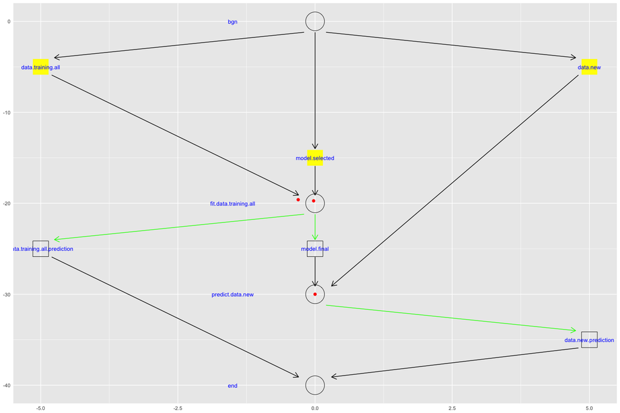

```r
glb_chunks_df <- myadd_chunk(glb_chunks_df, "fit.data.training", major.inc = TRUE)
```

```
##                label step_major step_minor label_minor     bgn     end
## 19        fit.models          8          3           3 110.982 115.611
## 20 fit.data.training          9          0           0 115.612      NA
##    elapsed
## 19    4.63
## 20      NA
```